# IND320_Del2_Datakilder

#### IND320 – Prosjektarbeid del 2: Datakilder

**Student:** Khalid Rashed  
**GitHub (gren `part2-work`):** https://github.com/khalidrashed/NMBU-IND320/tree/part2-work  
**Streamlit-app:** https://nmbu-ind320-khalid.streamlit.app/  
**ENTSO-E-side:** https://nmbu-ind320-khalid.streamlit.app/ENTSOE

##### Formål

Notebooken dokumenterer datakilder og analyse for IND320 del 2: NVE Magasinstatistikk API, ENTSO-E API, Cassandra/Spark, MongoDB og plott. Kjør cellene i rekkefølge. Kontroller at API-parametere, områdekoder og kolonnenavn stemmer med de faktiske responsene dine.

##### 1. Avhengigheter

Installer nødvendige Python-pakker i prosjektets virtuelle miljø. Spark/Cassandra krever i tillegg at connector og lokale tjenester er konfigurert etter kursboken.

```python
# Kjør i terminal ved behov:
# python -m pip install pandas matplotlib requests python-dotenv pymongo
# Spark og Cassandra connector må konfigureres separat.
```

##### 2. Importer biblioteker og last inn miljøvariabler

```python
import os
import xml.etree.ElementTree as ET
from datetime import datetime, timedelta, timezone

import pandas as pd
import matplotlib.pyplot as plt
import requests
from dotenv import load_dotenv
from pymongo import MongoClient

load_dotenv()
ENTSOE_API_TOKEN = os.getenv("ENTSOE_API_TOKEN")
MONGODB_URI = os.getenv("MONGODB_URI")

print("ENTSO-E token konfigurert:", bool(ENTSOE_API_TOKEN))
print("MongoDB URI konfigurert:", bool(MONGODB_URI))
```

```
ENTSO-E token konfigurert: True
MongoDB URI konfigurert: True
```

##### 3. NVE Magasinstatistikk API

Dokumentasjon:

- [NVE Magasinstatistikk API – Swagger](https://biapi.nve.no/magasinstatistikk/swagger/index.html)
- [NVE Magasinstatistikk](https://www.nve.no/energi/analyser-og-statistikk/magasinstatistikk/)

Koden under prøver å hente offentlig data fra API-et. Kontroller endepunkt og eventuelle parametere mot Swagger hvis API-et svarer med feil.

```python
NVE_URL = "https://biapi.nve.no/magasinstatistikk/api/Magasinstatistikk/HentOffentligData"

def get_nve_data(url=NVE_URL, params=None, timeout=30):
    response = requests.get(url, params=params, timeout=timeout)
    print("URL:", response.url, "| HTTP:", response.status_code)
    response.raise_for_status()
    payload = response.json()
    if isinstance(payload, list):
        return pd.json_normalize(payload)
    if isinstance(payload, dict):
        list_values = [v for v in payload.values() if isinstance(v, list)]
        return pd.json_normalize(list_values[0] if list_values else payload)
    raise ValueError("Uventet JSON-format")

try:
    nve_df = get_nve_data()
    print("Dimensjon:", nve_df.shape)
    display(nve_df.head())
    print("Kolonner:", nve_df.columns.tolist())
except Exception as exc:
    nve_df = pd.DataFrame()
    print("NVE-kallet må kontrolleres mot Swagger:", type(exc).__name__, exc)
```

```
URL: https://biapi.nve.no/magasinstatistikk/api/Magasinstatistikk/HentOffentligData | HTTP: 200
Dimensjon: (14922, 11)
```

|  | dato_Id | omrType | omrnr | iso_aar | iso_uke | fyllingsgrad | kapasitet_TWh | fylling_TWh | neste_Publiseringsdato | fyllingsgrad_forrige_uke | endring_fyllingsgrad |
| --- | --- | --- | --- | --- | --- | --- | --- | --- | --- | --- | --- |
| 0 | 1995-09-03 | EL | 4 | 1995 | 35 | 0.944721 | 21.079208 | 19.913979 | 0001-01-01T00:00:00 | 0.936888 | 0.007833 |
| 1 | 2020-11-15 | EL | 1 | 2020 | 46 | 0.974361 | 6.003264 | 5.849344 | 2020-11-25T13:00:00 | 0.997406 | -0.023046 |
| 2 | 2011-08-28 | EL | 4 | 2011 | 34 | 0.786499 | 21.079208 | 16.578772 | 0001-01-01T00:00:00 | 0.787193 | -0.000694 |
| 3 | 1998-07-05 | EL | 3 | 1998 | 27 | 0.793969 | 8.920932 | 7.082947 | 0001-01-01T00:00:00 | 0.733812 | 0.060157 |
| 4 | 2011-03-27 | EL | 4 | 2011 | 12 | 0.300820 | 21.079208 | 6.341054 | 0001-01-01T00:00:00 | 0.311122 | -0.010301 |

```
Kolonner: ['dato_Id', 'omrType', 'omrnr', 'iso_aar', 'iso_uke', 'fyllingsgrad', 'kapasitet_TWh', 'fylling_TWh', 'neste_Publiseringsdato', 'fyllingsgrad_forrige_uke', 'endring_fyllingsgrad']
```

```python
if not nve_df.empty:
    display(nve_df.dtypes.to_frame("datatype"))
    display(nve_df.isna().sum().to_frame("manglende verdier"))

# TODO: erstatt None med faktiske kolonnenavn fra NVE-responsen.
NVE_DATE_COLUMN = None
NVE_VALUE_COLUMN = None
NVE_AREA_COLUMN = None

if not nve_df.empty and NVE_DATE_COLUMN and NVE_VALUE_COLUMN:
    nve_plot = nve_df.copy()
    nve_plot[NVE_DATE_COLUMN] = pd.to_datetime(nve_plot[NVE_DATE_COLUMN], errors="coerce")
    nve_plot[NVE_VALUE_COLUMN] = pd.to_numeric(nve_plot[NVE_VALUE_COLUMN], errors="coerce")
    nve_plot = nve_plot.dropna(subset=[NVE_DATE_COLUMN, NVE_VALUE_COLUMN])

    if NVE_AREA_COLUMN and NVE_AREA_COLUMN in nve_plot.columns:
        print("Områder:", sorted(nve_plot[NVE_AREA_COLUMN].dropna().astype(str).unique()))

    ax = nve_plot.sort_values(NVE_DATE_COLUMN).plot(
        x=NVE_DATE_COLUMN, y=NVE_VALUE_COLUMN, figsize=(12, 5),
        title="NVE Magasinstatistikk – API-data"
    )
    ax.set_xlabel("Dato")
    ax.set_ylabel(NVE_VALUE_COLUMN)
    plt.tight_layout()
    plt.show()
else:
    print("Velg dato- og verdikolonne fra den faktiske NVE-responsen for å lage plottet.")
```

|  | datatype |
| --- | --- |
| dato_Id | object |
| omrType | object |
| omrnr | int64 |
| iso_aar | int64 |
| iso_uke | int64 |
| fyllingsgrad | float64 |
| kapasitet_TWh | float64 |
| fylling_TWh | float64 |
| neste_Publiseringsdato | object |
| fyllingsgrad_forrige_uke | float64 |
| endring_fyllingsgrad | float64 |

|  | manglende verdier |
| --- | --- |
| dato_Id | 0 |
| omrType | 0 |
| omrnr | 0 |
| iso_aar | 0 |
| iso_uke | 0 |
| fyllingsgrad | 0 |
| kapasitet_TWh | 0 |
| fylling_TWh | 0 |
| neste_Publiseringsdato | 0 |
| fyllingsgrad_forrige_uke | 0 |
| endring_fyllingsgrad | 0 |

```
Velg dato- og verdikolonne fra den faktiske NVE-responsen for å lage plottet.
```

##### 4. ENTSO-E API – siste to år

ENTSO-E API krever en token og riktige EIC-områdekoder. Bekreft parametere og koder i:

- [ENTSO-E API reference](https://documenter.getpostman.com/view/7009892/2s93JtP3F6)
- [ENTSO-E Transparency Platform](https://transparency.entsoe.eu/)

Dette eksemplet henter XML for ett områdepar. Fyll inn faktiske EIC-koder før du kjører det.

```python
ENTSOE_URL = "https://transparency.entsoe.eu/myAccount/webApiAccess"

def fetch_entsoe_flow(token, in_domain, out_domain, start, end, timeout=60):
    if not token:
        raise ValueError("ENTSOE_API_TOKEN mangler i miljøvariablene.")
    params = {
        "securityToken": token,
        "documentType": "A11",
        "in_Domain": in_domain,
        "out_Domain": out_domain,
        "periodStart": start.strftime("%Y%m%d%H%M"),
        "periodEnd": end.strftime("%Y%m%d%H%M"),
    }
    response = requests.get(ENTSOE_URL, params=params, timeout=timeout)
    print("HTTP:", response.status_code)
    response.raise_for_status()
    return response.text

# TODO: fyll inn gyldige EIC-koder fra ENTSO-E-dokumentasjonen.
ENTSOE_AREA_PAIRS = [
    # {"connection": "forbindelsesnavn", "in_domain": "EIC-kode", "out_domain": "EIC-kode"},
]

end_time = datetime.now(timezone.utc).replace(minute=0, second=0, microsecond=0)
start_time = end_time - timedelta(days=730)
entsoe_xml_responses = {}

if ENTSOE_API_TOKEN and ENTSOE_AREA_PAIRS:
    for pair in ENTSOE_AREA_PAIRS:
        try:
            entsoe_xml_responses[pair["connection"]] = fetch_entsoe_flow(
                ENTSOE_API_TOKEN, pair["in_domain"], pair["out_domain"], start_time, end_time
            )
            print(pair["connection"], "mottok XML-data.")
        except Exception as exc:
            print("Feil for", pair["connection"], ":", type(exc).__name__, exc)
else:
    print("ENTSOE_API_TOKEN eller ENTSOE_AREA_PAIRS mangler. Ingen kaller ble gjort.")
```

```
ENTSOE_API_TOKEN eller ENTSOE_AREA_PAIRS mangler. Ingen kaller ble gjort.
```

##### 4.1 XML-parser for ENTSO-E

Parseren under støtter vanlige 15-, 30- og 60-minutters oppløsninger. Kontroller den mot XML-responsen du faktisk får fra ENTSO-E før du bruker dataene videre.

```python
def parse_entsoe_xml(xml_text, connection, direction):
    root = ET.fromstring(xml_text)
    namespace = root.tag.split("}")[0].strip("{") if "}" in root.tag else None
    ns = {"e": namespace} if namespace else {}
    prefix = "e:" if namespace else ""

    rows = []
    for series in root.findall(f".//{prefix}TimeSeries", ns):
        period = series.find(f"{prefix}Period", ns)
        if period is None:
            continue
        start_node = period.find(f"{prefix}timeInterval/{prefix}start", ns)
        resolution_node = period.find(f"{prefix}resolution", ns)
        if start_node is None or resolution_node is None:
            continue
        period_start = pd.to_datetime(start_node.text, utc=True, errors="coerce")
        minutes = {"PT15M": 15, "PT30M": 30, "PT60M": 60}.get(resolution_node.text)
        if minutes is None:
            print("Ukjent oppløsning:", resolution_node.text)
            continue
        for point in period.findall(f"{prefix}Point", ns):
            pos = point.find(f"{prefix}position", ns)
            qty = point.find(f"{prefix}quantity", ns)
            if pos is None or qty is None:
                continue
            rows.append({
                "timestamp": period_start + pd.Timedelta(minutes=minutes * (int(pos.text) - 1)),
                "connection": connection,
                "direction": direction,
                "flow_mw": pd.to_numeric(qty.text, errors="coerce"),
            })
    return pd.DataFrame(rows)

entsoe_frames = []
for pair in ENTSOE_AREA_PAIRS:
    xml_text = entsoe_xml_responses.get(pair["connection"])
    if xml_text:
        try:
            entsoe_frames.append(parse_entsoe_xml(xml_text, pair["connection"], "cross-border"))
        except Exception as exc:
            print("Kunne ikke parse", pair["connection"], ":", exc)

entsoe_api_df = pd.concat(entsoe_frames, ignore_index=True) if entsoe_frames else pd.DataFrame()
print("Rader fra ENTSO-E API:", len(entsoe_api_df))
display(entsoe_api_df.head())
```

```
Rader fra ENTSO-E API: 0
```

##### 5. Cassandra og Spark

Oppgaven krever at ENTSO-E-data settes inn i Cassandra med Spark, og at relevante kolonner hentes ut med Spark. Host, keyspace, tabell, Spark-versjon og Cassandra-connector må passe med oppsettet ditt fra kursboken. Eksemplet under er med vilje kommentert ut til du har bekreftet disse innstillingene.

```python
# Eksempel – tilpass versjoner og navn til din installasjon:
#
# from pyspark.sql import SparkSession
# spark = (
#     SparkSession.builder
#     .appName("IND320-ENTSOE")
#     .config("spark.cassandra.connection.host", os.getenv("CASSANDRA_HOST", "127.0.0.1"))
#     # .config("spark.jars.packages", "com.datastax.spark:spark-cassandra-connector_<scala-version>:<version>")
#     .getOrCreate()
# )
#
# if not entsoe_api_df.empty:
#     spark_df = spark.createDataFrame(entsoe_api_df)
#     (spark_df.write.format("org.apache.spark.sql.cassandra")
#      .options(keyspace=os.getenv("CASSANDRA_KEYSPACE", "ind320"),
#               table=os.getenv("CASSANDRA_TABLE", "entsoe_crossborder_flows"))
#      .mode("append").save())
#
# # Hent relevante kolonner tilbake fra Cassandra:
# cassandra_df = (
#     spark.read.format("org.apache.spark.sql.cassandra")
#     .options(keyspace=os.getenv("CASSANDRA_KEYSPACE", "ind320"),
#              table=os.getenv("CASSANDRA_TABLE", "entsoe_crossborder_flows"))
#     .load().select("timestamp", "connection", "direction", "flow_mw")
# )
# cassandra_df.show(10, truncate=False)
# entsoe_spark_df = cassandra_df.toPandas()
```

##### 6. Les klargjorte ENTSO-E-data fra MongoDB

Denne delen bruker samlingen som Streamlit-siden din allerede forventer: `ind320.entsoe_crossborder_flows`. Dette gir et konkret datasett for plott. Det erstatter ikke dokumentasjon av Cassandra/Spark dersom de stegene ennå ikke er kjørt.

```python
def load_entsoe_from_mongodb(uri):
    if not uri:
        raise ValueError("MONGODB_URI mangler i miljøvariablene.")
    client = MongoClient(uri, serverSelectionTimeoutMS=10000)
    try:
        collection = client["ind320"]["entsoe_crossborder_flows"]
        projection = {
            "_id": 0, "timestamp": 1, "connection": 1,
            "from_area": 1, "to_area": 1, "direction": 1, "flow_mw": 1,
        }
        return pd.DataFrame(collection.find({}, projection))
    finally:
        client.close()

try:
    entsoe_df = load_entsoe_from_mongodb(MONGODB_URI)
    if not entsoe_df.empty:
        entsoe_df["timestamp"] = pd.to_datetime(entsoe_df["timestamp"], errors="coerce", utc=True)
        entsoe_df["flow_mw"] = pd.to_numeric(entsoe_df["flow_mw"], errors="coerce")
        entsoe_df = entsoe_df.dropna(subset=["timestamp", "connection", "direction", "flow_mw"])
    print("MongoDB-dimensjon:", entsoe_df.shape)
    display(entsoe_df.head())
except Exception as exc:
    entsoe_df = pd.DataFrame()
    print("Kunne ikke lese MongoDB:", type(exc).__name__, exc)
```

```
MongoDB-dimensjon: (945264, 6)
```

|  | timestamp | to_area | connection | from_area | direction | flow_mw |
| --- | --- | --- | --- | --- | --- | --- |
| 0 | 2024-10-14 22:00:00+00:00 | SE_3 | NO_1-SE_3 | NO_1 | from_Norway | 0.0 |
| 1 | 2024-10-14 23:00:00+00:00 | SE_3 | NO_1-SE_3 | NO_1 | from_Norway | 0.0 |
| 2 | 2024-10-15 00:00:00+00:00 | SE_3 | NO_1-SE_3 | NO_1 | from_Norway | 0.0 |
| 3 | 2024-10-15 01:00:00+00:00 | SE_3 | NO_1-SE_3 | NO_1 | from_Norway | 0.0 |
| 4 | 2024-10-15 02:00:00+00:00 | SE_3 | NO_1-SE_3 | NO_1 | from_Norway | 0.0 |

##### 7. Plott 1 – årlig import og eksport for en valgt forbindelse

Effekt måles i MW, mens energi måles i MWh. Estimatet beregner MW × antall timer til neste observasjon. Intervaller over én time ekskluderes fordi de kan inneholde manglende målinger. Tolk derfor kakediagrammet som et estimat, ikke et offisielt årsresultat.

```
Forbindelser: ['DE_LU-NO_2', 'DK_1-NO_2', 'FI-NO_4', 'GB-NO_2', 'NL-NO_2', 'NO_1-SE_3', 'NO_2-DE_LU', 'NO_2-DK_1', 'NO_2-GB', 'NO_2-NL', 'NO_3-SE_2', 'NO_4-FI', 'NO_4-SE_1', 'SE_1-NO_4', 'SE_2-NO_3', 'SE_3-NO_1']
År: [2024, 2025, 2026]
```

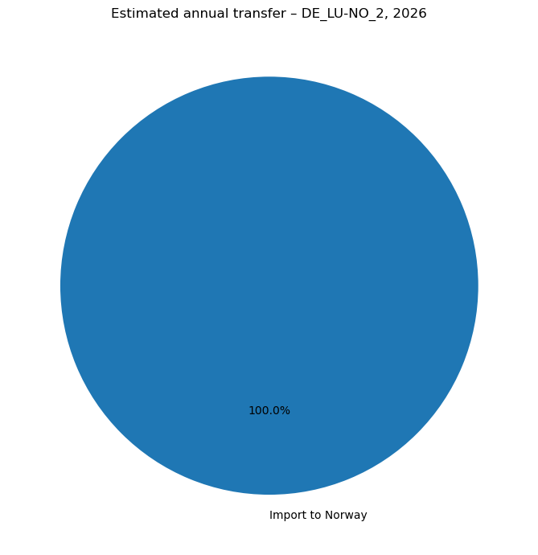

|  | direction | estimated_mwh | label |
| --- | --- | --- | --- |
| 0 | to_Norway | 2.251446e+06 | Import to Norway |

```python
if not entsoe_df.empty:
    plot_df = entsoe_df.copy()
    plot_df["year"] = plot_df["timestamp"].dt.year
    connections = sorted(plot_df["connection"].dropna().unique().tolist())
    years = sorted(plot_df["year"].dropna().unique().tolist())
    print("Forbindelser:", connections)
    print("År:", years)

    # Standardvalg. Endre etter å ha kontrollert listene ovenfor.
    SELECTED_CONNECTION = connections[0]
    SELECTED_YEAR = years[-1]

    annual = plot_df[(plot_df["connection"] == SELECTED_CONNECTION) &
                     (plot_df["year"] == SELECTED_YEAR)].copy()
    annual = annual.sort_values(["direction", "timestamp"])
    annual["next_timestamp"] = annual.groupby("direction")["timestamp"].shift(-1)
    annual["interval_hours"] = (annual["next_timestamp"] - annual["timestamp"]).dt.total_seconds() / 3600
    annual["interval_hours"] = annual["interval_hours"].where(annual["interval_hours"].between(0, 1))
    annual["estimated_mwh"] = annual["flow_mw"].abs() * annual["interval_hours"]
    energy = annual.dropna(subset=["estimated_mwh"]).groupby("direction", as_index=False)["estimated_mwh"].sum()

    labels = {"to_Norway": "Import to Norway", "from_Norway": "Export from Norway"}
    if not energy.empty and energy["estimated_mwh"].sum() > 0:
        energy["label"] = energy["direction"].map(lambda x: labels.get(x, x))
        plt.figure(figsize=(7, 7))
        plt.pie(energy["estimated_mwh"], labels=energy["label"], autopct="%1.1f%%", startangle=90)
        plt.title(f"Estimated annual transfer – {SELECTED_CONNECTION}, {SELECTED_YEAR}")
        plt.tight_layout()
        plt.show()
        display(energy)
    else:
        print("Ingen gyldige energiintervaller for valgt forbindelse og år.")
else:
    print("MongoDB-data mangler; kontroller URI og at samlingen inneholder data.")
```

##### 8. Plott 2 – linjediagram for en måned

Hver linje representerer en kombinasjon av forbindelse og retning. Velg år og måned etter at du har sett tilgjengelige data.

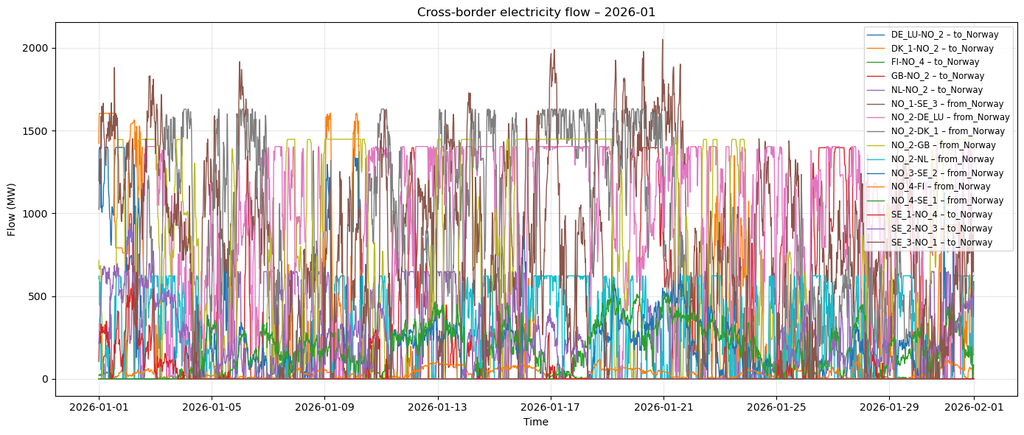

```python
if not entsoe_df.empty:
    plot_df = entsoe_df.copy()
    plot_df["year"] = plot_df["timestamp"].dt.year
    plot_df["month"] = plot_df["timestamp"].dt.month

    SELECTED_YEAR_LINE = int(plot_df["year"].max())
    SELECTED_MONTH = 1  # januar

    month_df = plot_df[(plot_df["year"] == SELECTED_YEAR_LINE) &
                       (plot_df["month"] == SELECTED_MONTH)].copy()
    if not month_df.empty:
        month_df["series"] = month_df["connection"].astype(str) + " – " + month_df["direction"].astype(str)
        fig, ax = plt.subplots(figsize=(14, 6))
        for label, group in month_df.groupby("series"):
            group = group.sort_values("timestamp")
            ax.plot(group["timestamp"], group["flow_mw"], label=label, linewidth=1)
        ax.set_title(f"Cross-border electricity flow – {SELECTED_YEAR_LINE}-{SELECTED_MONTH:02d}")
        ax.set_xlabel("Time")
        ax.set_ylabel("Flow (MW)")
        ax.legend(loc="best", fontsize="small")
        ax.grid(True, alpha=0.3)
        fig.tight_layout()
        plt.show()
    else:
        print("Ingen data for valgt måned og år.")
else:
    print("MongoDB-data mangler; linjediagrammet kan ikke lages.")
```

##### 9. Datakvalitet

Bruk de faktiske resultatene fra denne cellen i beskrivelsen din. Ikke oppgi tall før du har kjørt notebooken.

```python
if not entsoe_df.empty:
    print("Antall rader:", len(entsoe_df))
    print("Antall forbindelser:", entsoe_df["connection"].nunique())
    print("Retninger:", sorted(entsoe_df["direction"].dropna().unique().tolist()))
    print("Første tidsstempel:", entsoe_df["timestamp"].min())
    print("Siste tidsstempel:", entsoe_df["timestamp"].max())
    display(entsoe_df.isna().sum().to_frame("Manglende verdier"))
else:
    print("Ingen data tilgjengelig for kvalitetskontroll.")
```

```
Antall rader: 945264
Antall forbindelser: 16
Retninger: ['from_Norway', 'to_Norway']
Første tidsstempel: 2024-10-14 22:00:00+00:00
Siste tidsstempel: 2026-10-14 21:45:00+00:00
```

|  | Manglende verdier |
| --- | --- |
| timestamp | 0 |
| to_area | 0 |
| connection | 0 |
| from_area | 0 |
| direction | 0 |
| flow_mw | 0 |

##### 11. Beskrivelse av AI-bruk

Jeg brukte ChatGPT som støtte til å forstå feilmeldinger, strukturere Python-kode, feilsøke pakkeinstallasjoner og forbedre dokumentasjonen. Kodeforslag fra AI ble behandlet som utgangspunkt og må testes mot prosjektets faktiske API-responser, databaseoppsett og datastruktur. Jeg kontrollerte arbeidet ved å kjøre kode lokalt, undersøke kolonner og teste Streamlit-applikasjonen. Hemmeligheter som API-token og databasepassord skal lagres i miljøvariabler eller Streamlit Secrets, ikke i notebooken eller på GitHub.

##### 12. Arbeidslogg (utkast, 300–500 ord)

I del 2 av IND320 arbeidet jeg med å koble sammen eksterne datakilder, databaser og en Streamlit-applikasjon. Målet var å bruke API-er i stedet for å være avhengig av en lokal CSV-fil, og å gjøre dataene tilgjengelige både for analyse i Jupyter Notebook og for visning på nett.

Jeg undersøkte NVE sitt Magasinstatistikk API og arbeidet med å hente data direkte fra API-et. En viktig del av arbeidet er å kontrollere hvilke tidskolonner, områdekoder og måleverdier som finnes i responsen før dataene renses og plottes. API-data kan ha andre feltnavn eller formater enn en CSV-fil, så datoer og manglende verdier må håndteres eksplisitt. Målet er å gjenskape relevante figurer fra del 1 med data som hentes direkte fra NVE.

Jeg arbeidet også med ENTSO-E API for grensekryssende kraftflyt til og fra Norge. Dataene skal dekke de siste to årene. API-et krever en sikkerhetstoken og riktige områdekoder, og responsen må parses før dataene kan brukes videre. Dataflyten for oppgaven innebærer å bruke Spark til å lagre data i Cassandra og hente ut relevante kolonner. De klargjorte dataene lagres deretter i MongoDB slik at Streamlit-applikasjonen kan hente dem.

I Streamlit arbeidet jeg med en egen ENTSO-E-side med to kolonner. Den ene viser en årlig sammenligning av import og eksport for en valgt forbindelse, mens den andre viser kraftflyt over valgte måneder. Diagrammene bruker MW-observasjoner. Når årlig energi estimeres i MWh, må varigheten mellom observasjonene tas med i beregningen. Manglende eller lange intervaller kan påvirke estimatet, og dette må forklares for brukeren.

Jeg brukte ChatGPT som støtte for feilsøking, kodeforslag og dokumentasjon. Jeg måtte teste forslagene i mitt eget miljø, blant annet fordi Python-avhengigheter og konfigurasjon kan gi feil. Jeg lærte at hemmeligheter må lagres som miljøvariabler eller i Streamlit Secrets, og ikke i offentlig kode. Før innlevering må jeg kontrollere at alle celler kjører i riktig rekkefølge, verifisere API-parametere og områdekoder, kontrollere resultatene og eksportere notebooken til PDF.

##### 13. Referanser og prosjektlenker

- [NVE Magasinstatistikk API – Swagger](https://biapi.nve.no/magasinstatistikk/swagger/index.html)
- [NVE Magasinstatistikk](https://www.nve.no/energi/analyser-og-statistikk/magasinstatistikk/)
- [ENTSO-E API reference](https://documenter.getpostman.com/view/7009892/2s93JtP3F6)
- [ENTSO-E Transparency Platform](https://transparency.entsoe.eu/)
- [GitHub – part2-work](https://github.com/khalidrashed/NMBU-IND320/tree/part2-work)
- [Streamlit-app](https://nmbu-ind320-khalid.streamlit.app/)
- [ENTSO-E-side](https://nmbu-ind320-khalid.streamlit.app/ENTSOE)